Skip to main content

# Bulk RNA-seq differential expression

Example report: dexamethasone response in human airway smooth muscle cells

Published

November 13, 2026

**Note**

**This is a portfolio example built on public data.** It shows the structure, depth and turnaround-ready format of a standard bulk RNA-seq deliverable. Client reports follow the same layout, with the study’s own design, contrasts and questions.

## Summary

```r
suppressPackageStartupMessages({
  library(airway); library(DESeq2); library(apeglm); library(ggplot2); library(ggrepel)
  library(pheatmap); library(fgsea); library(msigdbr); library(AnnotationDbi); library(org.Hs.eg.db)
  library(dplyr); library(knitr)
})
theme_set(theme_minimal(base_size = 12))
fmt_p <- function(p) ifelse(is.na(p), "", ifelse(p < 1e-300, "< 1e-300", formatC(p, format = "e", digits = 1)))
fmt_fc <- function(l) ifelse(l >= 0, sprintf("%.1f\u00d7 up", 2^l), sprintf("%.1f\u00d7 down", 2^-l))
data(airway)
se <- airway
se$dex <- relevel(factor(se$dex), ref = "untrt")
se$cell <- factor(se$cell)
dds <- DESeqDataSet(se, design = ~ cell + dex)
keep <- rowSums(counts(dds) >= 10) >= 3
dds <- dds[keep, ]
dds <- DESeq(dds)
res <- results(dds, name = "dex_trt_vs_untrt", alpha = 0.05)
res_s <- lfcShrink(dds, coef = "dex_trt_vs_untrt", type = "apeglm", res = res)
sym <- mapIds(org.Hs.eg.db, keys = rownames(res_s), keytype = "ENSEMBL", column = "SYMBOL", multiVals = "first")
tab <- as.data.frame(res_s) |> mutate(gene_id = rownames(res_s), symbol = ifelse(is.na(sym), gene_id, sym)) |> arrange(padj)
sig <- tab |> filter(!is.na(padj), padj < 0.05)
up <- sum(sig$log2FoldChange > 1); down <- sum(sig$log2FoldChange < -1)
```

- **Design:** four primary airway smooth muscle cell lines, each treated with 1 µM dexamethasone for 18 hours or left untreated (8 samples, paired by donor). Data: Himes et al., *PLoS ONE* 2014 (GEO GSE52778), via the Bioconductor `airway` package.
- **Genes tested:** 16,596 genes with at least 10 reads in at least 3 samples.
- **Result:** 4,099 genes changed at a false discovery rate below 5%; 431 rose and 376 fell by more than two-fold.
- **Biology check:** the strongest responses include classic glucocorticoid-induced genes (shown below), which confirms the treatment worked and the analysis is oriented correctly.
- **Quality:** samples separate first by treatment and second by donor, with no outlier samples.

## Quality control

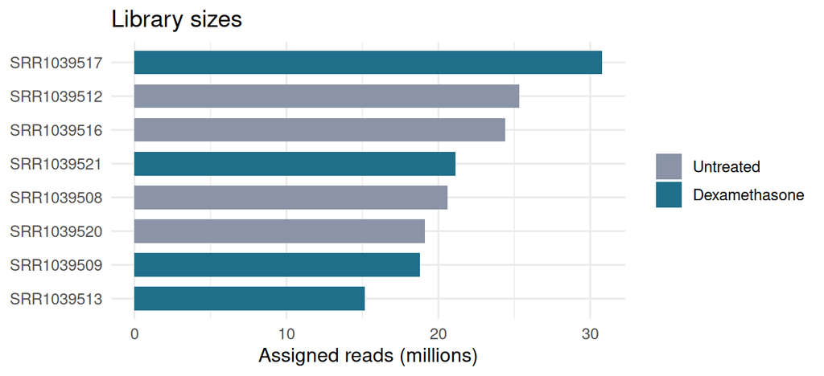

```r
ls <- data.frame(sample = colnames(dds), reads = colSums(counts(dds)) / 1e6, dex = dds$dex, cell = dds$cell)
ggplot(ls, aes(reorder(sample, reads), reads, fill = dex)) + geom_col(width = 0.7) + coord_flip() +
  scale_fill_manual(values = c(untrt = "#8a94a6", trt = "#1f6f8b"), labels = c("Untreated", "Dexamethasone")) +
  labs(x = NULL, y = "Assigned reads (millions)", fill = NULL, title = "Library sizes")
```

Library sizes range from 15.1 to 30.8 million reads, all adequate for gene-level analysis. Differences are absorbed by DESeq2’s size factors.

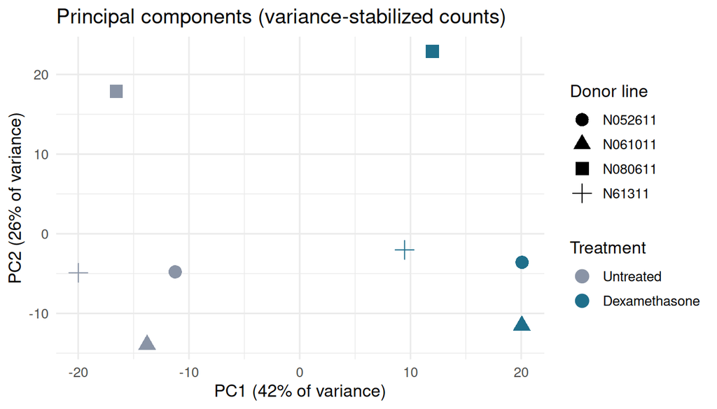

```r
vsd <- vst(dds, blind = TRUE)
pc <- plotPCA(vsd, intgroup = c("dex", "cell"), returnData = TRUE)
pv <- round(100 * attr(pc, "percentVar"))
ggplot(pc, aes(PC1, PC2, color = dex, shape = cell)) + geom_point(size = 4) +
  scale_color_manual(values = c(untrt = "#8a94a6", trt = "#1f6f8b"), labels = c("Untreated", "Dexamethasone")) +
  labs(x = paste0("PC1 (", pv[1], "% of variance)"), y = paste0("PC2 (", pv[2], "% of variance)"), color = "Treatment", shape = "Donor line",
       title = "Principal components (variance-stabilized counts)")
```

Treatment drives the first component and donor the second, which is why the model includes donor as a blocking factor (a paired design).

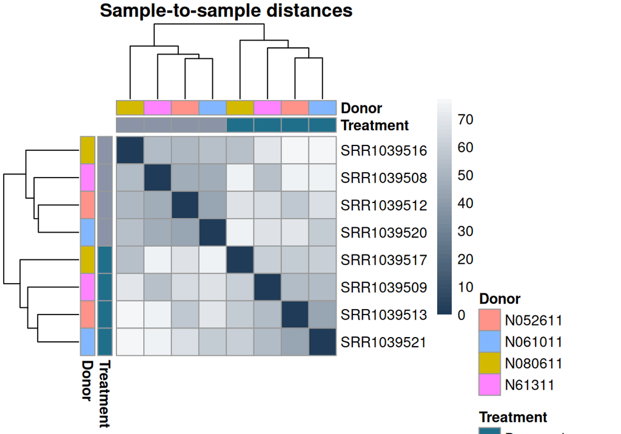

```r
d <- as.matrix(dist(t(assay(vsd))))
ann <- data.frame(Treatment = ifelse(vsd$dex == "trt", "Dexamethasone", "Untreated"), Donor = as.character(vsd$cell), row.names = colnames(vsd))
pheatmap(d, annotation_col = ann, annotation_row = ann, show_colnames = FALSE, main = "Sample-to-sample distances",
         color = colorRampPalette(c("#1f3b57", "#f4f6f8"))(50),
         annotation_colors = list(Treatment = c(Dexamethasone = "#1f6f8b", Untreated = "#8a94a6")))
```

## Differential expression

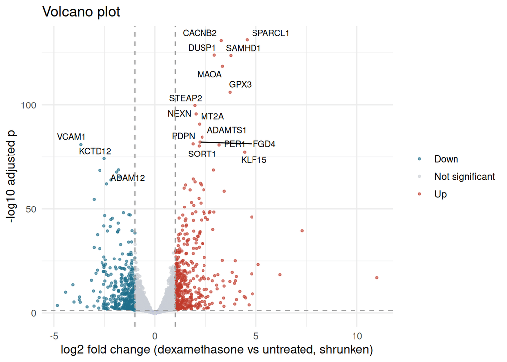

```r
tab$class <- with(tab, ifelse(!is.na(padj) & padj < 0.05 & log2FoldChange > 1, "Up",
                       ifelse(!is.na(padj) & padj < 0.05 & log2FoldChange < -1, "Down", "Not significant")))
lab <- tab |> filter(class != "Not significant") |> slice_min(padj, n = 18)
ggplot(tab |> filter(!is.na(padj)), aes(log2FoldChange, -log10(padj), color = class)) +
  geom_point(size = 0.8, alpha = 0.6) +
  geom_text_repel(data = lab, aes(label = symbol), size = 3, color = "black", max.overlaps = 30) +
  scale_color_manual(values = c(Up = "#c0392b", Down = "#1f6f8b", `Not significant` = "#c9ced6")) +
  geom_vline(xintercept = c(-1, 1), linetype = "dashed", color = "grey60") +
  geom_hline(yintercept = -log10(0.05), linetype = "dashed", color = "grey60") +
  labs(x = "log2 fold change (dexamethasone vs untreated, shrunken)", y = "-log10 adjusted p", color = NULL, title = "Volcano plot")
```

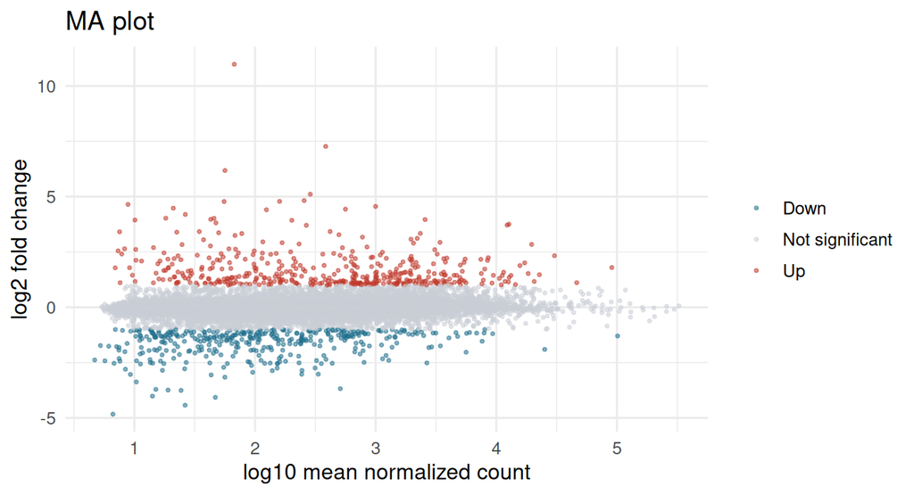

```r
ggplot(tab |> filter(baseMean > 0), aes(log10(baseMean), log2FoldChange, color = class)) + geom_point(size = 0.6, alpha = 0.5) +
  scale_color_manual(values = c(Up = "#c0392b", Down = "#1f6f8b", `Not significant` = "#c9ced6")) +
  labs(x = "log10 mean normalized count", y = "log2 fold change", color = NULL, title = "MA plot")
```

### Top genes

```r
kable(tab |> filter(!is.na(padj)) |> slice_min(padj, n = 20) |>
        transmute(Gene = symbol, `Ensembl ID` = gene_id, `Mean count` = format(round(baseMean), big.mark = ","), `log2 FC` = round(log2FoldChange, 2),
                  Change = fmt_fc(log2FoldChange), `Adjusted p` = fmt_p(padj)), align = "llrrrr", row.names = FALSE)
```

| Gene | Ensembl ID | Mean count | log2 FC | Change | Adjusted p |
| --- | --- | --- | --- | --- | --- |
| SPARCL1 | ENSG00000152583 | 998 | 4.56 | 23.5× up | 3.6e-132 |
| CACNB2 | ENSG00000165995 | 496 | 3.28 | 9.7× up | 8.6e-132 |
| DUSP1 | ENSG00000120129 | 3,413 | 2.94 | 7.7× up | 1.2e-124 |
| SAMHD1 | ENSG00000101347 | 12,718 | 3.76 | 13.5× up | 1.9e-124 |
| MAOA | ENSG00000189221 | 2,344 | 3.34 | 10.1× up | 2.6e-119 |
| GPX3 | ENSG00000211445 | 12,303 | 3.71 | 13.1× up | 6.0e-107 |
| STEAP2 | ENSG00000157214 | 3,013 | 1.97 | 3.9× up | 2.0e-100 |
| NEXN | ENSG00000162614 | 5,400 | 2.02 | 4.1× up | 2.2e-96 |
| MT2A | ENSG00000125148 | 3,660 | 2.20 | 4.6× up | 1.5e-91 |
| ADAMTS1 | ENSG00000154734 | 30,352 | 2.33 | 5.0× up | 2.4e-85 |
| FGD4 | ENSG00000139132 | 1,225 | 2.22 | 4.6× up | 5.2e-83 |
| PDPN | ENSG00000162493 | 1,101 | 1.88 | 3.7× up | 3.8e-82 |
| VCAM1 | ENSG00000162692 | 509 | -3.68 | 12.8× down | 8.7e-82 |
| PER1 | ENSG00000179094 | 777 | 3.17 | 9.0× up | 1.3e-81 |
| SORT1 | ENSG00000134243 | 5,518 | 2.18 | 4.5× up | 3.8e-81 |
| KLF15 | ENSG00000163884 | 562 | 4.43 | 21.6× up | 3.3e-78 |
| KCTD12 | ENSG00000178695 | 2,656 | -2.52 | 5.7× down | 5.8e-75 |
| ADAM12 | ENSG00000148848 | 1,368 | -1.81 | 3.5× down | 1.5e-69 |
| CCDC69 | ENSG00000198624 | 2,060 | 2.90 | 7.5× up | 1.8e-69 |
| PRSS35 | ENSG00000146250 | 314 | -2.74 | 6.7× down | 2.6e-69 |

### Known glucocorticoid-response genes

```r
known <- c("FKBP5", "TSC22D3", "PER1", "KLF15", "DUSP1", "ZBTB16", "CRISPLD2")
kable(tab |> filter(symbol %in% known) |> arrange(desc(log2FoldChange)) |> transmute(Gene = symbol, `log2 FC` = round(log2FoldChange, 2), Change = fmt_fc(log2FoldChange), `Adjusted p` = fmt_p(padj)), align = "lrrr", row.names = FALSE)
```

| Gene | log2 FC | Change | Adjusted p |
| --- | --- | --- | --- |
| ZBTB16 | 7.27 | 154.4× up | 2.6e-40 |
| KLF15 | 4.43 | 21.6× up | 3.3e-78 |
| FKBP5 | 3.97 | 15.6× up | 8.5e-26 |
| PER1 | 3.17 | 9.0× up | 1.3e-81 |
| TSC22D3 | 3.11 | 8.7× up | 3.6e-19 |
| DUSP1 | 2.94 | 7.7× up | 1.2e-124 |
| CRISPLD2 | 2.60 | 6.1× up | 1.1e-45 |

These genes are textbook targets of the glucocorticoid receptor; CRISPLD2 was the gene highlighted in the original study. Seeing them near the top of the list is the main sanity check that the contrast is the right way round.

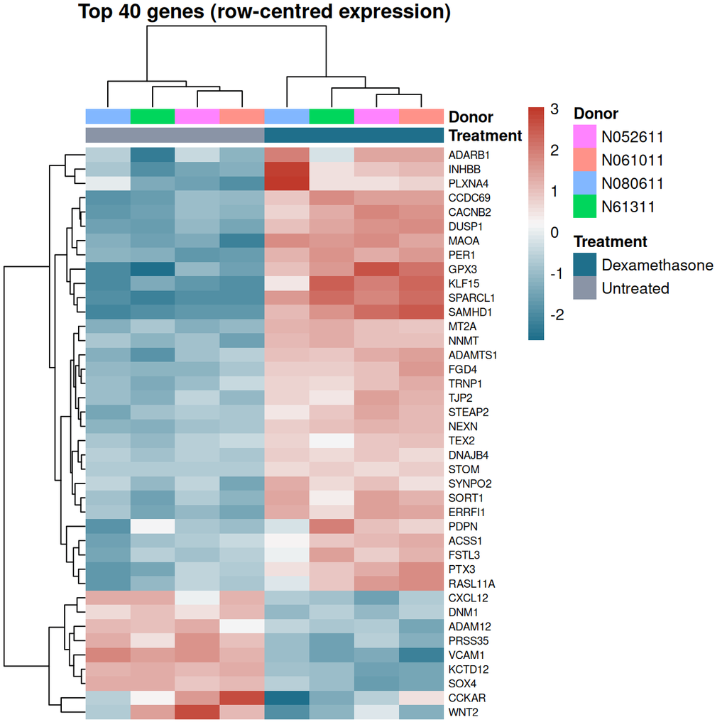

```r
top <- tab |> filter(!is.na(padj)) |> slice_min(padj, n = 40)
m <- assay(vst(dds))[top$gene_id, ]
m <- m - rowMeans(m); rownames(m) <- top$symbol
pheatmap(m, annotation_col = ann, show_colnames = FALSE, fontsize_row = 7, main = "Top 40 genes (row-centred expression)",
         color = colorRampPalette(c("#1f6f8b", "#f7f7f7", "#c0392b"))(60), border_color = NA,
         annotation_colors = list(Treatment = c(Dexamethasone = "#1f6f8b", Untreated = "#8a94a6")))
```

## Pathways

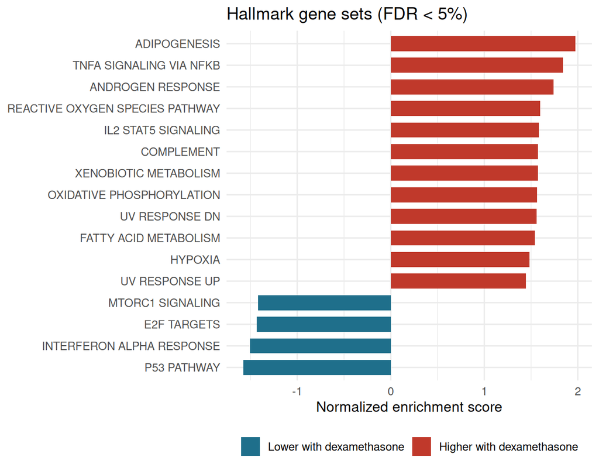

```r
h <- msigdbr(species = "Homo sapiens", collection = "H")
sets <- split(h$ensembl_gene, h$gs_name)
st <- res$stat; names(st) <- rownames(res); st <- sort(st[!is.na(st)], decreasing = TRUE)
set.seed(1)
gs <- fgsea(sets, st, minSize = 15, maxSize = 500)
gs <- gs |> arrange(padj)
showp <- gs |> filter(padj < 0.05) |> slice_max(abs(NES), n = 16) |> mutate(pathway = gsub("HALLMARK_", "", pathway) |> gsub(pattern = "_", replacement = " "))
ggplot(showp, aes(NES, reorder(pathway, NES), fill = NES > 0)) + geom_col(width = 0.7) +
  scale_fill_manual(values = c(`TRUE` = "#c0392b", `FALSE` = "#1f6f8b"), labels = c(`TRUE` = "Higher with dexamethasone", `FALSE` = "Lower with dexamethasone")) +
  labs(x = "Normalized enrichment score", y = NULL, fill = NULL, title = "Hallmark gene sets (FDR < 5%)") + theme(legend.position = "bottom")
```

Gene set enrichment on the full ranked list (no cut-off) found 18 of the 50 Hallmark sets changed at FDR below 5%.

## Methods (ready to paste into a manuscript)

> Gene-level read counts for eight samples (four donor airway smooth muscle cell lines, each untreated or treated with 1 µM dexamethasone for 18 h; GEO GSE52778) were obtained from the Bioconductor `airway` package. Genes with at least 10 counts in at least three samples were retained (16,596 genes). Differential expression was tested with DESeq2 (v1.52.0) using a paired design (~ donor + treatment); log2 fold changes were shrunk with apeglm, and p-values were adjusted with the Benjamini–Hochberg procedure. Genes with adjusted p < 0.05 were considered significant. Gene set enrichment analysis against the MSigDB Hallmark collection was performed with fgsea (v1.38.0) on genes ranked by the DESeq2 Wald statistic. Analyses were run in R 4.6.2.

## Deliverables in a client project

- This report (HTML and PDF), with all figures as separate high-resolution PNG and vector PDF files
- Full results table for every gene (Excel and CSV): counts, fold changes, p-values, gene annotations
- Normalized expression matrix and the analysis code, so results can be reproduced
- A 30-minute call to walk through the findings

**Software versions**